# Markov, Higher-Order, and Simplicial Analysis

# Purpose

This tutorial moves beyond a first look at a transition network. It covers:

- passage times and Markov stability;
- Markov order and higher-order pathways;
- path anomalies;
- simplicial summaries of network shape.

# Passage Times and Markov Stability

The `trajectories` data set has three engagement states over time.

```r
data(trajectories)
df <- as.data.frame(trajectories)

net <- build_network(df, method = "relative")
round(net$weights, 3)
```

```
#>            Active Average Disengaged
#> Active      0.698   0.267      0.035
#> Average     0.204   0.610      0.186
#> Disengaged  0.120   0.397      0.483
```

`passage_time()` computes expected time to reach one state from another.

```r
pt <- passage_time(net)
pt
```

```
#> Mean First Passage Times (3 states)
#>
#>            Active Average Disengaged
#> Active        2.7     3.6       10.4
#> Average       5.5     2.3        8.0
#> Disengaged    6.2     2.8        5.4
#>
#> Stationary distribution:
#>     Active    Average Disengaged
#>     0.3719     0.4431     0.1850
```

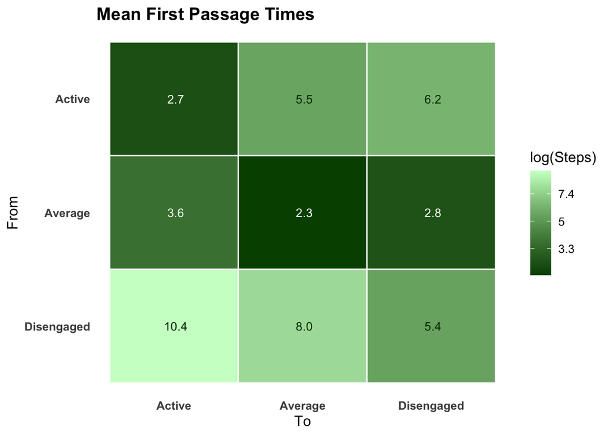

```r
plot(pt)
```

The diagonal is the expected return time. Off-diagonal cells are expected first passage times.

`markov_stability()` summarizes each state.

```r
ms <- markov_stability(net)
ms
```

```
#> Markov Stability Analysis
#>
#>       state persistence stationary_prob return_time sojourn_time
#>      Active      0.6976          0.3719        2.69         3.31
#>     Average      0.6099          0.4431        2.26         2.56
#>  Disengaged      0.4831          0.1850        5.41         1.93
#>  avg_time_to_others avg_time_from_others
#>                6.99                 5.84
#>                6.74                 3.20
#>                4.47                 9.16
```

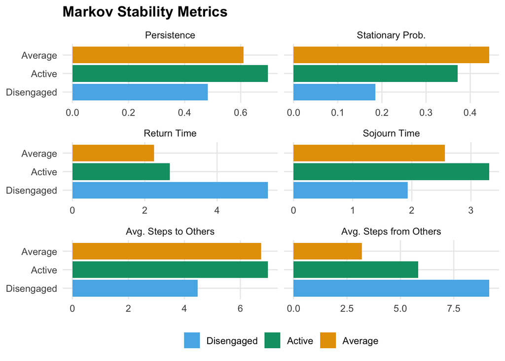

```r
plot(ms)
```

Important quantities include persistence, stationary probability, return time, sojourn time, and accessibility from other states.

## A Subgroup Comparison

Filter learners who are active more than half the observed time.

```r
active_count <- rowSums(df == "Active", na.rm = TRUE)
mostly_active <- df[active_count > ncol(df) / 2, ]

net_active <- build_network(mostly_active, method = "relative")
round(net_active$weights, 3)
```

```
#>            Active Average Disengaged
#> Active      0.819   0.164      0.017
#> Average     0.683   0.288      0.029
#> Disengaged  0.643   0.143      0.214
```

```r
passage_time(net_active)
```

```
#> Mean First Passage Times (3 states)
#>
#>            Active Average Disengaged
#> Active        1.3     6.1       52.0
#> Average       1.5     5.4       51.3
#> Disengaged    1.5     6.3       41.7
#>
#> Stationary distribution:
#>     Active    Average Disengaged
#>     0.7895     0.1866     0.0240
```

```r
markov_stability(net_active)
```

```
#> Markov Stability Analysis
#>
#>       state persistence stationary_prob return_time sojourn_time
#>      Active      0.8191          0.7895        1.27         5.53
#>     Average      0.2885          0.1866        5.36         1.41
#>  Disengaged      0.2143          0.0240       41.75         1.27
#>  avg_time_to_others avg_time_from_others
#>               29.06                 1.50
#>               26.38                 6.20
#>                3.91                51.64
```

This is a descriptive subgroup comparison. For formal edge-level comparison, use permutation tests on grouped networks.

# Higher-Order Analysis

Now use the human-AI action sequences. A first-order network asks what follows the current action. Higher-order analysis asks whether earlier context changes the next action.

```r
data(human_long)

set.seed(3)
sessions <- sample(unique(human_long$session_id), 160)
human_sub <- human_long[human_long$session_id %in% sessions, ]

human_net <- build_network(
  human_sub,
  method = "relative",
  action = "code",
  actor = "session_id",
  time = "timestamp"
)

human_net
```

```
#> Transition Network (relative probabilities) [directed]
#>   Weights: [0.012, 0.587]  |  mean: 0.111
#>
#>   Weight matrix:
#>             Command Correct Frustrate Inquire Interrupt Refine Request Specify
#>   Command     0.256   0.085     0.045   0.065     0.036  0.040   0.168   0.257
#>   Correct     0.099   0.089     0.145   0.064     0.064  0.103   0.121   0.266
#>   Frustrate   0.096   0.123     0.186   0.066     0.033  0.159   0.099   0.156
#>   Inquire     0.170   0.148     0.072   0.204     0.097  0.063   0.091   0.104
#>   Interrupt   0.255   0.076     0.090   0.131     0.128  0.048   0.062   0.141
#>   Refine      0.070   0.091     0.074   0.053     0.053  0.107   0.119   0.420
#>   Request     0.098   0.017     0.046   0.101     0.058  0.029   0.029   0.587
#>   Specify     0.259   0.053     0.091   0.072     0.185  0.050   0.061   0.188
#>             Verify
#>   Command    0.048
#>   Correct    0.050
#>   Frustrate  0.081
#>   Inquire    0.050
#>   Interrupt  0.069
#>   Refine     0.012
#>   Request    0.035
#>   Specify    0.041
#>    [ reached 'max' / getOption("max.print") -- omitted 1 row ]
#>
#>   Initial probabilities:
#>   Specify       0.678  ████████████████████████████████████████
#>   Command       0.171  ██████████
#>   Request       0.050  ███
#>   Interrupt     0.035  ██
#>   Frustrate     0.020  █
#>   Refine        0.020  █
#>   Inquire       0.015  █
#>   Correct       0.010  █
#>   Verify        0.000
```

## Markov Order With MOGen

`build_mogen()` fits models at increasing order and reports information criteria.

```r
mg <- build_mogen(human_net, max_order = 3)
summary(mg)
```

```
#> Multi-Order Generative Model (MOGen) Summary
#>
#>   States: Command, Correct, Frustrate, Inquire, Interrupt, Refine, Request, Specify, Verify
#>   Paths: 190 | Observations: 3840
#>
#>   Optimal order: 3 (by aic)
```

|  | order | layer_dof | cum_dof | loglik | aic | bic | selected |
| --- | --- | --- | --- | --- | --- | --- | --- |
| order_0 | 0 | 8 | 8 | -7849.09 | 15714.17 | 15764.20 |  |
| order_1 | 1 | 72 | 80 | -7411.91 | 14983.83 | 15484.09 |  |
| order_2 | 2 | 519 | 599 | -6793.58 | 14785.16 | 18530.85 |  |
| order_3 | 3 | 1187 | 1786 | -5107.62 | 13787.23 | 24955.50 | <-- |

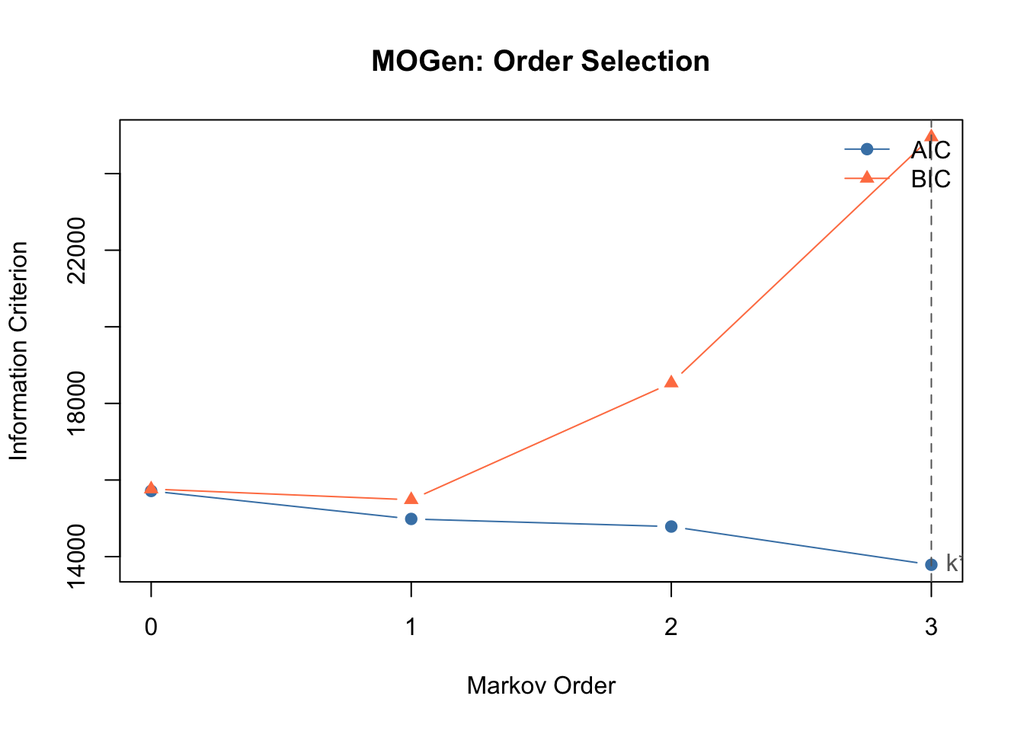

```r
plot(mg)
```

Extract order-specific transitions:

```r
head(mogen_transitions(mg, order = 2), 12)
```

|  | path | count | probability | from | to |
| --- | --- | --- | --- | --- | --- |
| 1 | Specify -> Command -> Specify | 93 | 0.3765 | Specify -> Command | Specify |
| 2 | Command -> Request -> Specify | 87 | 0.7565 | Command -> Request | Specify |
| 3 | Specify -> Command -> Request | 81 | 0.3279 | Specify -> Command | Request |
| 4 | Command -> Command -> Command | 80 | 0.4790 | Command -> Command | Command |
| 5 | Request -> Specify -> Interrupt | 70 | 0.3889 | Request -> Specify | Interrupt |
| 6 | Command -> Specify -> Interrupt | 55 | 0.3143 | Command -> Specify | Interrupt |
| 7 | Specify -> Specify -> Specify | 53 | 0.3081 | Specify -> Specify | Specify |
| 8 | Specify -> Interrupt -> Command | 48 | 0.2981 | Specify -> Interrupt | Command |
| 9 | Request -> Specify -> Specify | 36 | 0.2000 | Request -> Specify | Specify |
| 10 | Specify -> Request -> Specify | 32 | 0.5517 | Specify -> Request | Specify |

[output cut: 2 more lines]

If a higher order is preferred, the next state depends on more than the current state. If order 1 is preferred, local higher-order patterns may still exist.

## Higher-Order Network

`build_hon()` identifies contexts where adding history changes the outgoing transition distribution.

```r
hon <- build_hon(human_net)
hon
```

```
#> Higher-Order Network (HON)
#>   Nodes:        553 (9 first-order states)
#>   Edges:        1944
#>   Max order:    5 (requested 5)
#>   Min freq:     1
#>   Trajectories: 190
```

```r
head(hon$ho_edges[order(-hon$ho_edges$count), ], 12)
```

|  | path | from | to | count | probability | from_order | to_order |
| --- | --- | --- | --- | --- | --- | --- | --- |
| 1448 | Specify -> Command | Specify | Command | 250 | 0.25906736 | 1 | 2 |
| 1247 | Request -> Specify | Request | Specify | 203 | 0.58670520 | 1 | 2 |
| 8 | Command -> Specify | Command | Specify | 181 | 0.25710227 | 1 | 2 |
| 1455 | Specify -> Specify | Specify | Specify | 181 | 0.18756477 | 1 | 2 |
| 1 | Command -> Command | Command | Command | 180 | 0.25568182 | 1 | 2 |
| 1452 | Specify -> Interrupt | Specify | Interrupt | 179 | 0.18549223 | 1 | 2 |
| 7 | Command -> Request | Command | Request | 118 | 0.16761364 | 1 | 2 |
| 1075 | Refine -> Specify | Refine | Specify | 102 | 0.41975309 | 1 | 2 |
| 1464 | Specify -> Command -> Specify | Specify -> Command | Specify | 93 | 0.37651822 | 2 | 3 |
| 1450 | Specify -> Frustrate | Specify | Frustrate | 88 | 0.09119171 | 1 | 2 |

[output cut: 2 more lines]

Focus on higher-order edges where the context-specific probability differs meaningfully from the first-order pattern.

## Common Paths

`path_counts()` is descriptive. It lists observed paths by frequency.

```r
path_counts(human_net, k = 3, top = 15)
```

|  | path | count | proportion |
| --- | --- | --- | --- |
| 1 | Specify -> Command -> Specify | 93 | 0.0269 |
| 2 | Command -> Request -> Specify | 87 | 0.0251 |
| 3 | Specify -> Command -> Request | 81 | 0.0234 |
| 4 | Command -> Command -> Command | 80 | 0.0231 |
| 5 | Request -> Specify -> Interrupt | 70 | 0.0202 |
| 6 | Command -> Specify -> Interrupt | 55 | 0.0159 |
| 7 | Specify -> Specify -> Specify | 53 | 0.0153 |
| 8 | Specify -> Interrupt -> Command | 48 | 0.0139 |
| 9 | Request -> Specify -> Specify | 36 | 0.0104 |
| 10 | Specify -> Request -> Specify | 32 | 0.0092 |

[output cut: 5 more lines]

Common paths are not automatically surprising. They may be common because their individual states are common.

## Path Anomalies

`build_hypa()` tests which paths occur more or less often than expected.

```r
hypa <- build_hypa(human_net)
hypa
```

```
#> HYPA: Path Anomaly Detection
#>   Order k:      3
#>   Edges:        1778
#>   Anomalous:    22 (alpha=0.05, p_adjust=BH)
#>     Over-repr:  8
#>     Under-repr: 14
```

```r
head(hypa$over, 10)
```

|  | path | from | to | observed | expected | ratio | p_value | anomaly | p_adjusted_under | p_adjusted_over |
| --- | --- | --- | --- | --- | --- | --- | --- | --- | --- | --- |
| 949 | Specify -> Interrupt -> Refine -> Specify | Specify -> Interrupt -> Refine | Specify | 8 | 1.693231 | 4.724695 | 0.9999448 | over | 1 | 0.00489722 |
| 826 | Specify -> Inquire -> Specify -> Command | Specify -> Inquire -> Specify | Command | 5 | 1.231441 | 4.060285 | 0.9984923 | over | 1 | 0.01212972 |
| 640 | Verify -> Frustrate -> Verify -> Frustrate | Verify -> Frustrate -> Verify | Frustrate | 5 | 1.293013 | 3.866938 | 0.9980636 | over | 1 | 0.01477676 |
| 1695 | Frustrate -> Verify -> Frustrate -> Refine | Frustrate -> Verify -> Frustrate | Refine | 5 | 1.293013 | 3.866938 | 0.9980636 | over | 1 | 0.01477676 |
| 982 | Specify -> Interrupt -> Verify -> Command | Specify -> Interrupt -> Verify | Command | 7 | 2.339737 | 2.991789 | 0.9974001 | over | 1 | 0.01672615 |
| 602 | Specify -> Frustrate -> Request -> Specify | Specify -> Frustrate -> Request | Specify | 5 | 1.800982 | 2.776263 | 0.9902564 | over | 1 | 0.03269388 |
| 940 | Interrupt -> Interrupt -> Interrupt -> Interrupt | Interrupt -> Interrupt -> Interrupt | Interrupt | 16 | 6.141810 | 2.605095 | 0.9998057 | over | 1 | 0.00489722 |
| 627 | Correct -> Frustrate -> Specify -> Specify | Correct -> Frustrate -> Specify | Specify | 5 | 1.939519 | 2.577959 | 0.9863224 | over | 1 | 0.03830392 |

```r
head(hypa$under, 10)
```

|  | path | from | to | observed | expected | ratio | p_value | anomaly | p_adjusted_under | p_adjusted_over |
| --- | --- | --- | --- | --- | --- | --- | --- | --- | --- | --- |
| 223 | Specify -> Command -> Specify -> Specify | Specify -> Command -> Specify | Specify | 5 | 36.41986 | 0.1372877 | 6.505489e-11 | under | 3.855586e-08 | 1 |
| 1617 | Specify -> Specify -> Specify -> Specify | Specify -> Specify -> Specify | Specify | 6 | 40.79147 | 0.1470896 | 9.424483e-12 | under | 1.632353e-08 | 1 |
| 1288 | Command -> Request -> Specify -> Specify | Command -> Request -> Specify | Specify | 8 | 44.17793 | 0.1810859 | 1.836167e-11 | under | 1.632353e-08 | 1 |
| 1274 | Specify -> Request -> Specify -> Interrupt | Specify -> Request -> Specify | Interrupt | 6 | 30.35501 | 0.1976609 | 6.877671e-08 | under | 2.038083e-05 | 1 |
| 189 | Specify -> Command -> Specify -> Command | Specify -> Command -> Specify | Command | 9 | 40.62215 | 0.2215540 | 1.697605e-09 | under | 6.036683e-07 | 1 |
| 199 | Specify -> Command -> Specify -> Frustrate | Specify -> Command -> Specify | Frustrate | 6 | 22.41222 | 0.2677111 | 3.793734e-05 | under | 4.496839e-03 | 1 |
| 1282 | Command -> Request -> Specify -> Request | Command -> Request -> Specify | Request | 5 | 17.67117 | 0.2829467 | 3.743459e-04 | under | 2.773279e-02 | 1 |
| 33 | Command -> Command -> Command -> Specify | Command -> Command -> Command | Specify | 7 | 24.56724 | 0.2849323 | 2.711153e-05 | under | 3.443164e-03 | 1 |
| 1480 | Request -> Specify -> Interrupt -> Command | Request -> Specify -> Interrupt | Command | 15 | 45.07073 | 0.3328102 | 1.431496e-07 | under | 3.636001e-05 | 1 |
| 8 | Specify -> Command -> Command -> Command | Specify -> Command -> Command | Command | 13 | 30.81680 | 0.4218478 | 2.193137e-04 | under | 1.856856e-02 | 1 |

Over-represented paths are routines that occur more than the null model expects. Under-represented paths are sequences that are avoided relative to that expectation.

# Simplicial Analysis

Simplicial analysis treats groups of connected nodes as higher-dimensional objects. It is a way to describe the shape of the network, not just the list of edges.

```r
sc <- build_simplicial(human_net, threshold = 0.05)
sc
```

```
#> Clique Complex
#>   9 nodes, 511 simplices, dimension 8
#>   Density: 100.0%  |  Mean dim: 3.51  |  Euler: 1
#>   f-vector: (f0=9 f1=36 f2=84 f3=126 f4=126 f5=84 f6=36 f7=9 f8=1)
#>   Betti: b0=1
#>   Nodes: Command, Correct, Frustrate, Inquire, Interrupt, Refine, Request, Specify, Verify
```

```r
betti_numbers(sc)
```

```
#> b0 b1 b2 b3 b4 b5 b6 b7 b8
#>  1  0  0  0  0  0  0  0  0
```

```r
euler_characteristic(sc)
```

```
#> [1] 1
```

```r
simplicial_degree(sc)
```

|  | node | d0 | d1 | d2 | d3 | d4 | d5 | d6 | d7 | d8 | total |
| --- | --- | --- | --- | --- | --- | --- | --- | --- | --- | --- | --- |
| 1 | Command | 1 | 8 | 28 | 56 | 70 | 56 | 28 | 8 | 1 | 255 |
| 2 | Correct | 1 | 8 | 28 | 56 | 70 | 56 | 28 | 8 | 1 | 255 |
| 3 | Frustrate | 1 | 8 | 28 | 56 | 70 | 56 | 28 | 8 | 1 | 255 |
| 4 | Inquire | 1 | 8 | 28 | 56 | 70 | 56 | 28 | 8 | 1 | 255 |
| 5 | Interrupt | 1 | 8 | 28 | 56 | 70 | 56 | 28 | 8 | 1 | 255 |
| 6 | Refine | 1 | 8 | 28 | 56 | 70 | 56 | 28 | 8 | 1 | 255 |
| 7 | Request | 1 | 8 | 28 | 56 | 70 | 56 | 28 | 8 | 1 | 255 |
| 8 | Specify | 1 | 8 | 28 | 56 | 70 | 56 | 28 | 8 | 1 | 255 |
| 9 | Verify | 1 | 8 | 28 | 56 | 70 | 56 | 28 | 8 | 1 | 255 |

Read Betti numbers as:

- beta 0: connected components;
- beta 1: loops;
- beta 2: enclosed voids.

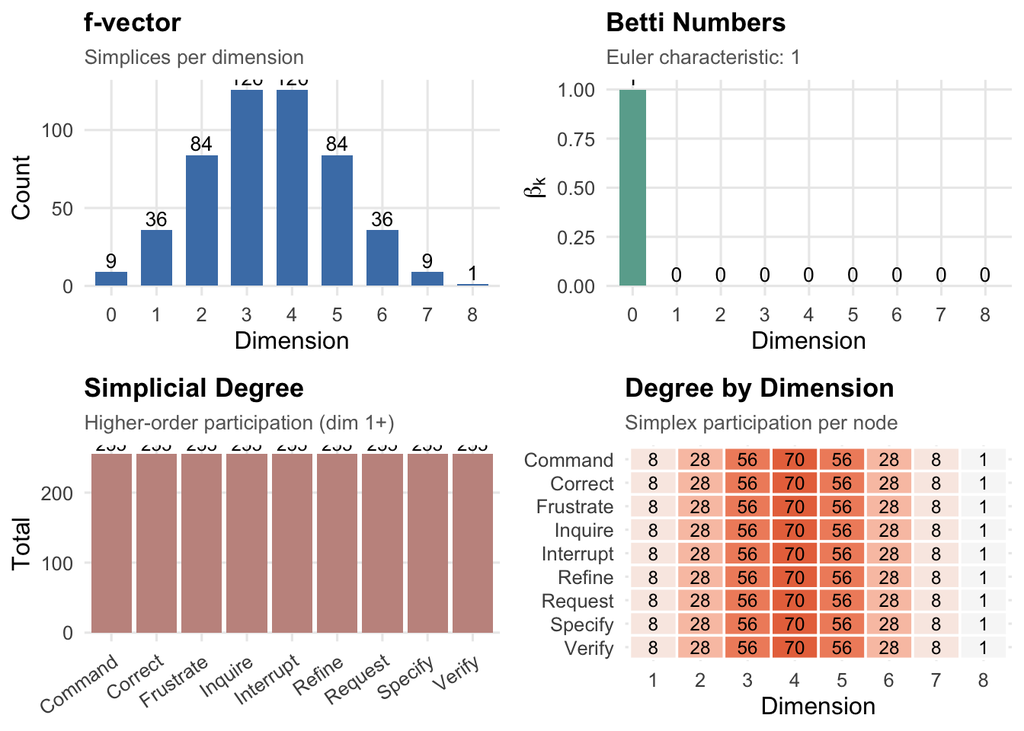

```r
plot(sc)
```

Persistent homology varies the threshold and tracks which topological features persist.

```r
ph <- persistent_homology(human_net, n_steps = 20)
ph
```

```
#> Persistent Homology
#>   20 filtration steps [0.5867 → 0.0059]
#>   Features: b0: 9 (1 persistent)  |  b1: 2 (0 persistent)  |  b3: 70 (70 persistent)
#>   Longest-lived:
#>     b0: 0.5867 → 0.0000 (life: 0.5867)
#>     b0: 0.5867 → 0.1587 (life: 0.4280)
#>     b0: 0.5867 → 0.1587 (life: 0.4280)
```

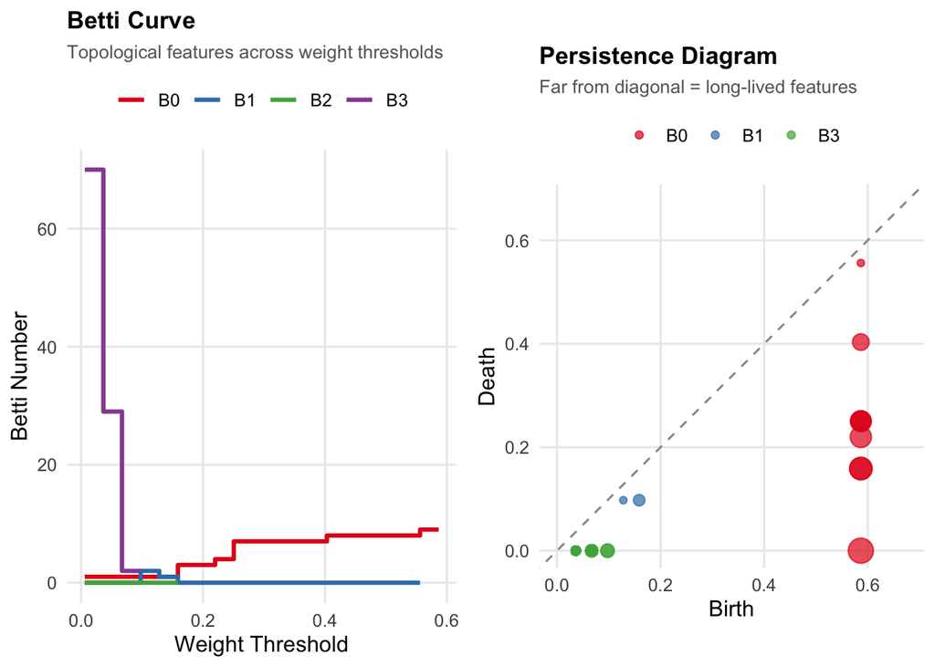

```r
plot(ph)
```

Q-analysis studies connectivity through shared faces.

```r
qa <- q_analysis(sc)
qa
```

```
#> Q-Analysis (max q = 8)
#>   Components: q8:1 q7:1 q6:1 q5:1 q4:1 q3:1 q2:1 q1:1 q0:1
#>   Fully connected at all q levels
#>   Structure: Command:8 Correct:8 Frustrate:8 Inquire:8 Interrupt:8 Refine:8 Request:8 Specify:8 Verify:8
```

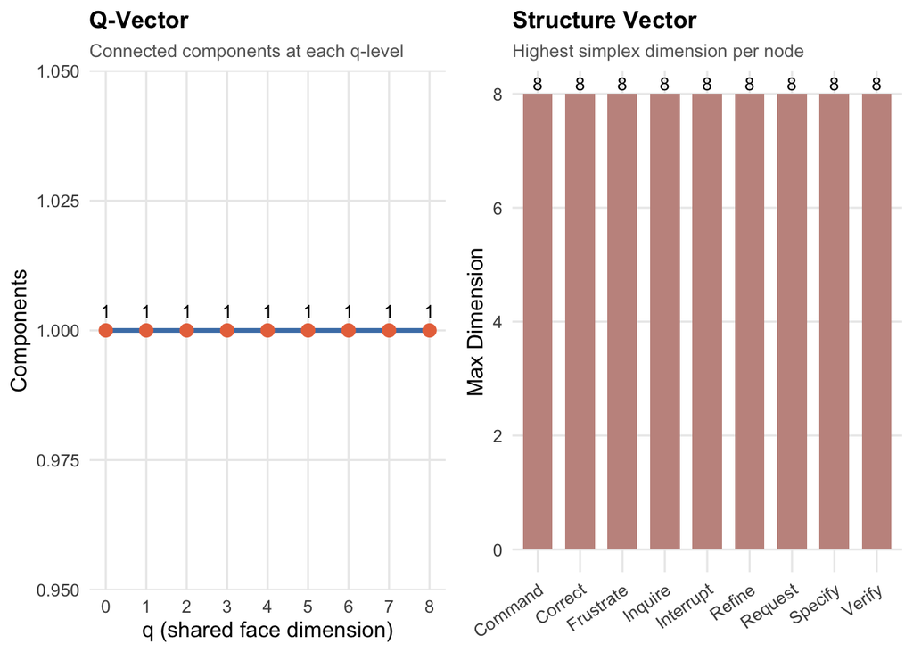

```r
plot(qa)
```

# Practical Reading Order

Use the methods in this order:

1. Estimate and validate a first-order transition network.
2. Use `passage_time()` and `markov_stability()` to describe movement.
3. Use `build_mogen()` to check whether higher order is needed globally.
4. Use `build_hon()` and `path_counts()` to inspect local pathways.
5. Use `build_hypa()` when the question is statistical surprise.
6. Use simplicial tools when the question is network shape.